# Project2

**Dataset Summary:**

**What is it?:** My dataset contains statistics on over 17,000 soccer players from the fifa video game. Some of the notable statistics are: transfer value, age, position, rating, potential, etc.

**Where did I find it?:** I found my dataset on Kaggle.com

**Why should you care?:** The reason this dataset is fascinating is because the sample size contains the entire scope of every major soccer league around the world, including fairly accurate for statistics for each player in said league, which allows us to answer some intersting questions.

**Link to dataset:** https://www.kaggle.com/datasets/maso0dahmed/football-players-data

Below I am importing numpy and pandas which will allow for easier data wrangling:

```python
import numpy as np
import pandas as pd
```

Below we use python pandas to read in our csv file

I also have a line to view the columns of our csv file

```python
path = "/workspaces/codespaces-jupyter/data/fifa_players.csv"
data = pd.read_csv(path)
data
```

|  | name | full_name | birth_date | age | height_cm | weight_kgs | positions | nationality | overall_rating | potential | ... | long_shots | aggression | interceptions | positioning | vision | penalties | composure | marking | standing_tackle | sliding_tackle |
| --- | --- | --- | --- | --- | --- | --- | --- | --- | --- | --- | --- | --- | --- | --- | --- | --- | --- | --- | --- | --- | --- |
| 0 | L. Messi | Lionel Andrés Messi Cuccittini | 6/24/1987 | 31 | 170.18 | 72.1 | CF,RW,ST | Argentina | 94 | 94 | ... | 94 | 48 | 22 | 94 | 94 | 75 | 96 | 33 | 28 | 26 |
| 1 | C. Eriksen | Christian Dannemann Eriksen | 2/14/1992 | 27 | 154.94 | 76.2 | CAM,RM,CM | Denmark | 88 | 89 | ... | 89 | 46 | 56 | 84 | 91 | 67 | 88 | 59 | 57 | 22 |
| 2 | P. Pogba | Paul Pogba | 3/15/1993 | 25 | 190.50 | 83.9 | CM,CAM | France | 88 | 91 | ... | 82 | 78 | 64 | 82 | 88 | 82 | 87 | 63 | 67 | 67 |
| 3 | L. Insigne | Lorenzo Insigne | 6/4/1991 | 27 | 162.56 | 59.0 | LW,ST | Italy | 88 | 88 | ... | 84 | 34 | 26 | 83 | 87 | 61 | 83 | 51 | 24 | 22 |
| 4 | K. Koulibaly | Kalidou Koulibaly | 6/20/1991 | 27 | 187.96 | 88.9 | CB | Senegal | 88 | 91 | ... | 15 | 87 | 88 | 24 | 49 | 33 | 80 | 91 | 88 | 87 |
| ... | ... | ... | ... | ... | ... | ... | ... | ... | ... | ... | ... | ... | ... | ... | ... | ... | ... | ... | ... | ... | ... |
| 17949 | R. McKenzie | Rory McKenzie | 10/7/1993 | 25 | 175.26 | 74.8 | RM,CAM,CM | Scotland | 67 | 70 | ... | 54 | 69 | 41 | 60 | 64 | 63 | 56 | 40 | 20 | 18 |
| 17950 | M. Sipľak | Michal Sipľak | 2/2/1996 | 23 | 182.88 | 79.8 | LB | Slovakia | 59 | 67 | ... | 22 | 62 | 55 | 42 | 39 | 32 | 52 | 53 | 64 | 60 |
| 17951 | J. Bekkema | Jan Bekkema | 4/9/1996 | 22 | 185.42 | 89.8 | GK | Netherlands | 59 | 67 | ... | 9 | 27 | 10 | 5 | 25 | 16 | 47 | 9 | 12 | 13 |
| 17952 | A. Al Yami | Abdulrahman Al Yami | 6/19/1997 | 21 | 175.26 | 64.9 | ST,LM | Saudi Arabia | 59 | 71 | ... | 58 | 38 | 15 | 54 | 52 | 50 | 53 | 16 | 18 | 17 |
| 17953 | Júnior Brumado | José Francisco dos Santos Júnior | 5/15/1999 | 19 | 190.50 | 79.8 | ST | Brazil | 59 | 75 | ... | 53 | 67 | 20 | 53 | 49 | 52 | 45 | 23 | 31 | 21 |

17954 rows × 51 columns

Below I am importing the matplotlib package which will allow me to easily plot elements of my dataset

**Question 1:**

The first question I want to answer, is how much of a correlation is there between potential and the value of a player?

You may be wondering, why do I care? Player transfers work differently in soccer than they do in the NFL or NBA. In the NFL, if I want to acquire a player, I will send the other team one of my players and/or a draft pick. In soccer, if I want to aquire a player from a different club, I would send them a transfer fee to aquire the players contract.

```python
import matplotlib.pyplot as plt
```

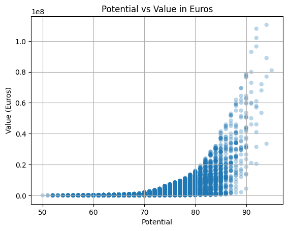

```python
np.random.seed(19680801)

fig, ax = plt.subplots()


ax.scatter(data['potential'], data['value_euro'], alpha=0.3, edgecolors='none')

ax.grid(True)
plt.xlabel('Potential')
plt.ylabel('Value (Euros)')
plt.title('Potential vs Value in Euros')

plt.show()
```

We see above, that there is only a correlation between potential and value, when we look at players with a 70 potential or above. It then begins to look like a growth function.

**Question 2:**

I would next like to take a look at players as a whole, and see if there is any kind of correlation between overall Rating and Wage.

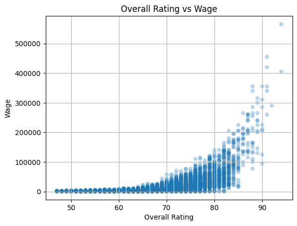

```python
np.random.seed(19680801)

fig, ax = plt.subplots()


ax.scatter(data['overall_rating'], data['wage_euro'], alpha=0.3, edgecolors='none')

ax.grid(True)
plt.xlabel('Overall Rating')
plt.ylabel('Wage')
plt.title('Overall Rating vs Wage')

plt.show()
```

- It appears that there is more of a correlation when evaluating this question.
- Until the rating reaches about 70 the wages remain fairly low, but then there is an exponential increase in Rating vs Wage.

**Question 3:**

Do taller players have better heading accuracy?

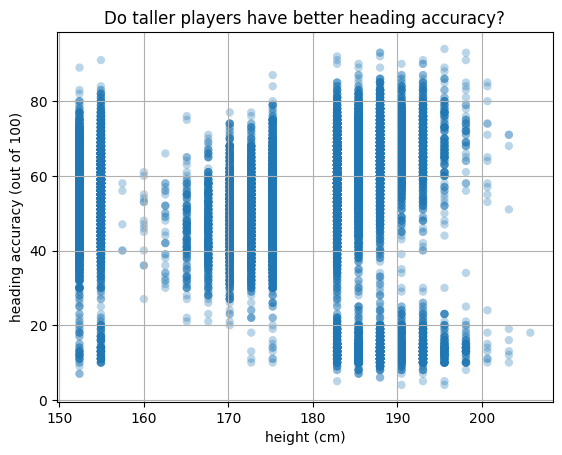

```python
np.random.seed(19680801)

fig, ax = plt.subplots()


ax.scatter(data['height_cm'], data['heading_accuracy'], alpha=0.3, edgecolors='none')

ax.grid(True)
plt.xlabel('height (cm)')
plt.ylabel('heading accuracy (out of 100)')
plt.title('Do taller players have better heading accuracy?')

plt.show()
```

- Surprisingly, it doesn't appear that there is any sort of relationship between height, and how accurately soccer players can head the ball.
- I find this surprising, because you would think that taller players would have a considerable advantage in how accurately they head the ball, as you would assume you need more height to accurately head a soccer ball.

**Question 4:** At what age do players transfer values start to decrease?

**Why is this intersting?:** This is intersting, because this essentialy answers the question, around what age do soccer players peak?

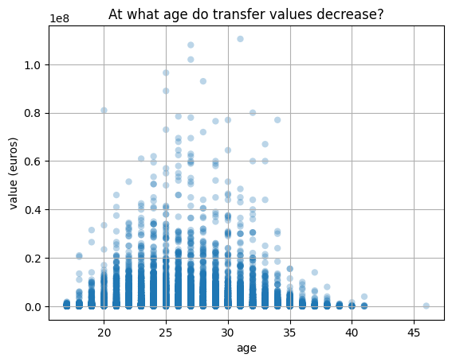

```python
np.random.seed(19680801)

fig, ax = plt.subplots()


ax.scatter(data['age'], data['value_euro'], alpha=0.3, edgecolors='none')

ax.grid(True)
plt.xlabel('age')
plt.ylabel('value (euros)')
plt.title('At what age do transfer values decrease?')

plt.show()
```

**What does this graph tell us?:**

It tells us that, on average, soccer players peak around the ages of 25 to 27 excluding some outliers.

**Question 5:**

Another question I have is, do left or right footed players have better finishing. For those reading this who don't know what finishing is, it describes a players ability to score goals. A player like Lionel Messi who is incredibly gifted at scoring would have a very high score for finishing, whereas someone who isn't as gifted, would have a lower score.

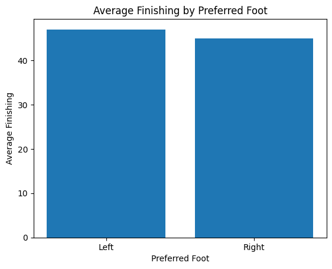

```python
grouped = data.groupby('preferred_foot')['finishing'].mean()


plt.bar(grouped.index, grouped.values)


plt.xlabel('Preferred Foot')
plt.ylabel('Average Finishing')
plt.title('Average Finishing by Preferred Foot')

plt.show()
```

Based on the results of the bar chart, I find it very surprising that the average finishing ratings of left and right footed players are similar, as I know that left footed players are more desirable.

**Question 6:**

Something else I have been wondering about, how much of an advanatage does height give you in soccer, especially depending on your position? Sports like american football, height clearly gives you an advantage, but in soccer do you have more of an advantage, or less, because your center of gravity isn't as low to the ground.

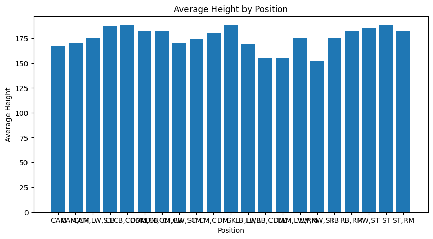

```python
sample = data.iloc[::500, :]
group = sample.groupby('positions')['height_cm'].mean()
plt.figure(figsize = (10,5))
plt.bar(group.index, group.values)
plt.xlabel('Position')
plt.ylabel('Average Height')
plt.title('Average Height by Position')
plt.show()
```

While this bar chart sort of gives us an idea of the average heights for each position, it still has yet to answer the question, how adventageous is height, and can that vary based on position?

Below I sampled every 50 entries of my csv file, and then created a scatter plot showing the overall of the players on the x-axis, and the height on the y-axis, with the dots on the plot color coded to different positions.

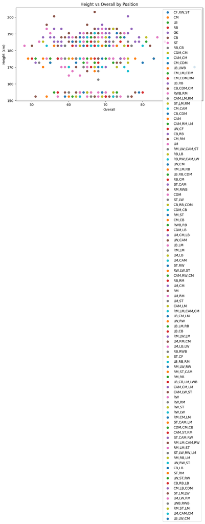

```python
sample1 = data.iloc[::50, :]
positions = sample1['positions'].unique()
plt.figure(figsize=(10, 5))

for position in positions:
    subset = sample1[sample1['positions'] == position]
    plt.scatter(subset['overall_rating'], subset['height_cm'], label=position)

plt.xlabel('Overall')
plt.ylabel('Height (cm)')
plt.title('Height vs Overall by Position')
plt.legend()

plt.show()
```

What does this plot tell us? It tells us that, aside from goalkeepers, height doesn't have much of a correlation to how good a player is.